# Forecasting with ARIMA models

#### Exploring auto.arima() options

The `auto.arima()` function needs to estimate a lot of different models, and various short-cuts are used to try to make the function as fast as possible. This can cause a model to be returned which does not actually have the smallest AICc value. To make `auto.arima()` work harder to find a good model, add the optional argument `stepwise = FALSE` to look at a much larger collection of models.

Here, you will try finding an ARIMA model for the pre-loaded `euretail` data, which contains quarterly retail trade in the Euro area from 1996-2011. Inspect it in the console before beginning this exercise.

```r
# Find an ARIMA model for euretail
fit1 <- auto.arima(euretail)

# Don't use a stepwise search
fit2 <- auto.arima(euretail, stepwise = FALSE)
summary(fit1)
```

```
## Series: euretail
## ARIMA(1,1,2)(0,1,1)[4]
##
## Coefficients:
##          ar1      ma1     ma2     sma1
##       0.7362  -0.4663  0.2163  -0.8433
## s.e.  0.2243   0.1990  0.2101   0.1876
##
## sigma^2 estimated as 0.1587:  log likelihood=-29.62
## AIC=69.24   AICc=70.38   BIC=79.63
##
## Training set error measures:
##                       ME      RMSE       MAE         MPE      MAPE
## Training set -0.03183461 0.3693126 0.2788867 -0.03031231 0.2889988
##                   MASE       ACF1
## Training set 0.2268601 0.01482898
```

```r
summary(fit2)
```

```
## Series: euretail
## ARIMA(0,1,3)(0,1,1)[4]
##
## Coefficients:
##          ma1     ma2     ma3     sma1
##       0.2630  0.3694  0.4200  -0.6636
## s.e.  0.1237  0.1255  0.1294   0.1545
##
## sigma^2 estimated as 0.156:  log likelihood=-28.63
## AIC=67.26   AICc=68.39   BIC=77.65
##
## Training set error measures:
##                       ME      RMSE       MAE         MPE      MAPE
## Training set -0.02965298 0.3661147 0.2787802 -0.02795377 0.2885545
##                   MASE        ACF1
## Training set 0.2267735 0.006455781
```

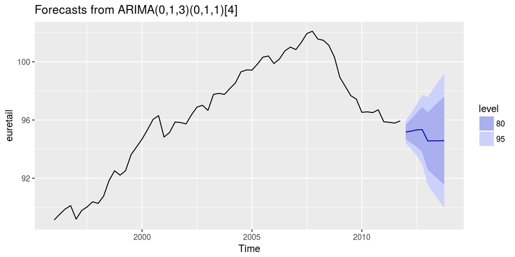

```r
# AICc of better model
AICc <- 68.39

# Compute 2-year forecasts from better model
fit2 %>% forecast(h = 8) %>% autoplot()
```

#### Comparing auto.arima() and ets() on seasonal data

What happens when you want to create training and test sets for data that is more frequent than yearly? If needed, you can use a vector in form `c(year, period)` for the `start` and/or `end` keywords in the `window()` function. You must also ensure that you’re using the appropriate values of `h` in forecasting functions. Recall that h should be equal to the length of the data that makes up your test set.

For example, if your data spans 15 years, your training set consists of the first 10 years, and you intend to forecast the last 5 years of data, you would use `h = 12 * 5` not `h = 5` because your test set would include 60 monthly observations. If instead your training set consists of the first 9.5 years and you want forecast the last 5.5 years, you would use `h = 66` to account for the extra 6 months.

In the final exercise for this chapter, you will compare seasonal ARIMA and ETS models applied to the quarterly cement production data `qcement`. Because the series is very long, you can afford to use a training and test set rather than time series cross-validation. This is much faster.

```r
# Use 20 years of the qcement data beginning in 1988
train <- window(qcement, start = c(1988, 1), end = c(2007, 4))

# Fit an ARIMA and an ETS model to the training data
fit1 <- auto.arima(train, stepwise = FALSE)
fit2 <- ets(train)
summary(fit1)
```

```
## Series: train
## ARIMA(1,0,1)(2,1,1)[4] with drift
##
## Coefficients:
##          ar1      ma1   sar1     sar2     sma1   drift
##       0.8886  -0.2366  0.081  -0.2345  -0.8979  0.0105
## s.e.  0.0842   0.1334  0.157   0.1392   0.1780  0.0029
##
## sigma^2 estimated as 0.01146:  log likelihood=61.47
## AIC=-108.95   AICc=-107.3   BIC=-92.63
##
## Training set error measures:
##                        ME      RMSE        MAE        MPE     MAPE
## Training set -0.006205705 0.1001195 0.07988903 -0.6704455 4.372443
##                   MASE        ACF1
## Training set 0.5458078 -0.01133907
```

```r
summary(fit2)
```

```
## ETS(M,N,M)
##
## Call:
##  ets(y = train)
##
##   Smoothing parameters:
##     alpha = 0.7341
##     gamma = 1e-04
##
##   Initial states:
##     l = 1.6439
##     s=1.031 1.0439 1.0103 0.9148
##
##   sigma:  0.0585
##
##        AIC       AICc        BIC
## -2.1967020 -0.6411464 14.4774845
##
## Training set error measures:
##                      ME      RMSE        MAE       MPE     MAPE      MASE
## Training set 0.01406512 0.1022079 0.07958478 0.4938163 4.371823 0.5437292
##                     ACF1
## Training set -0.03346295
```

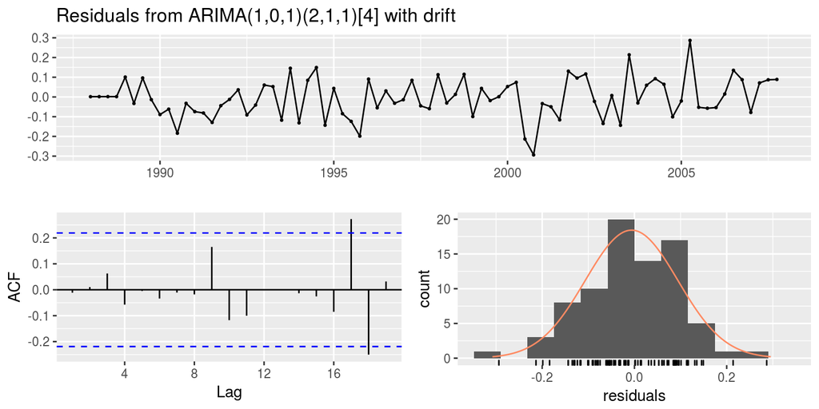

```
##
##  Ljung-Box test
##
## data:  Residuals from ARIMA(1,0,1)(2,1,1)[4] with drift
## Q* = 3.3058, df = 3, p-value = 0.3468
##
## Model df: 6.   Total lags used: 9
```

```r
# Check that both models have white noise residuals
# ggAcf(fit1$residuals)
# ggAcf(fit2$residuals)
checkresiduals(fit1)
```

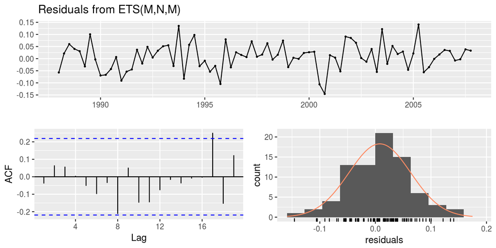

```
##
##  Ljung-Box test
##
## data:  Residuals from ETS(M,N,M)
## Q* = 6.3457, df = 3, p-value = 0.09595
##
## Model df: 6.   Total lags used: 9
```

```r
checkresiduals(fit2)
```

```r
# Produce forecasts for each model
fc1 <- forecast(fit1, h = 25)
fc2 <- forecast(fit2, h = 25)

# Use accuracy() to find better model based on RMSE
accuracy(fc1, qcement)
```

```
##                        ME      RMSE        MAE        MPE     MAPE
## Training set -0.006205705 0.1001195 0.07988903 -0.6704455 4.372443
## Test set     -0.158835254 0.1996098 0.16882205 -7.3332836 7.719241
##                   MASE        ACF1 Theil's U
## Training set 0.5458078 -0.01133907        NA
## Test set     1.1534049  0.29170452 0.7282225
```

```r
accuracy(fc2, qcement)
```

```
##                       ME      RMSE        MAE        MPE     MAPE
## Training set  0.01406512 0.1022079 0.07958478  0.4938163 4.371823
## Test set     -0.13495518 0.1838791 0.15395142 -6.2508985 6.986077
##                   MASE        ACF1 Theil's U
## Training set 0.5437292 -0.03346295        NA
## Test set     1.0518076  0.53438368  0.680556
```

```r
bettermodel <- fit2
```

#### HINT

- In window(), start is equal to the starting year of the qcement data, 1988, and end is in the format c(YYYY, Q). Use head() and tail() on qcement if you’re not sure what these dates are.
- The last data point in qcement is in the first quarter of 2014, and the last data point in the training set is in the fourth quarter of 2007. Therefore, h in forecast() is equal to `1+(4∗(2013−2007))`.
- You do not need to set up a test set. Just pass the whole of qcement as the test set to accuracy() and it will find the relevant part to use in comparing with the forecasts.